# Data Visualization with ggplot2

## What is the difference?

### `geom_col` vs. `geom_bar`

This is the difference:

```r
# Drawing the column
ggplot(eg2_transformed,
       aes(x = education, y = n)) +
  geom_col()
```

```r
# Drawing the bar
ggplot(eg2,
       aes(x = education)) +
  geom_bar()
```

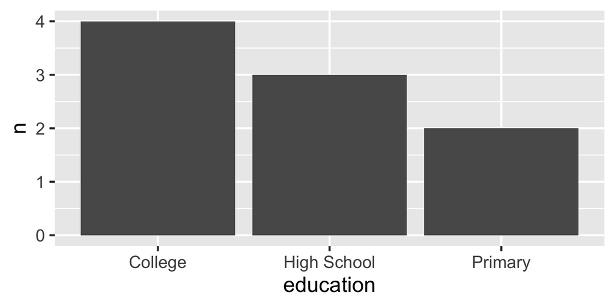

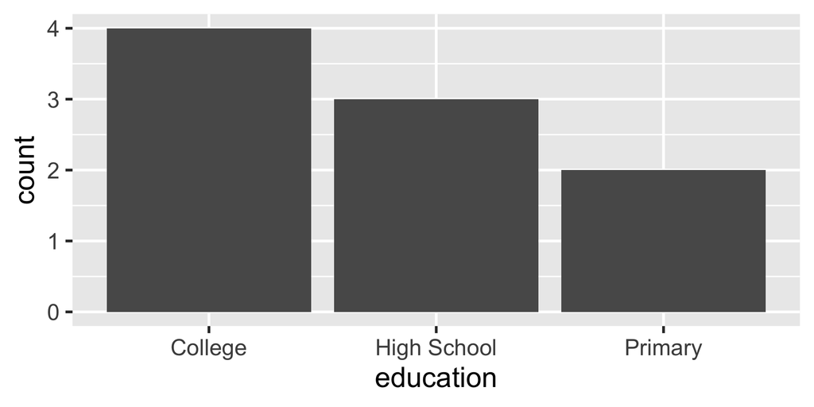

## Simple Geoms

### `geom_text`

Suppose we collected a small survey and just recorded the education level of each respondent. We want to visualize how many respondents fall into each category.

```r
# Drawing the column
ggplot(eg2_transformed, aes(x = education, y = n)) +
  geom_col() +
  geom_text(
    aes(label = education, y = n/2))
```

[figure not shown]

## Simple Geoms

### `geom_text`

We can also use `geom_text` with the first example:

Imagine we have data about 9 countries that records their level of democracy from -10 to +10 (x-axis) and their GDP per capita in $1,000s (y-axis).

```r
eg1 <- data.frame(
  democracy = c(-8, -7, -5, -3, 0, 2, 5, 8, 9),   # democracy score
  gdp = c(2, 9, 4, 7, 8, 20, 15, 25, 27),  # GDP per capita in $1000s
  country = c(
    "North Korea",   # very autocratic, very poor
    "Saudi Arabia",  # autocratic, but richer due to oil
    "Zimbabwe",      # authoritarian, low GDP
    "Russia",        # hybrid regime, middle income
    "Nigeria",       # similar position
    "India",         # low–mid democracy, growing GDP
    "Brazil",        # democracy, mid GDP
    "Poland",        # consolidated democracy, higher GDP
    "South Korea"   # rich democracy
  ))
```

## Simple Geoms

### `geom_text`

We can also use `geom_text` with the first example:

Imagine we have data about 9 countries that records their level of democracy from -10 to +10 (x-axis) and their GDP per capita in $1,000s (y-axis).

| democracy | gdp | country |
| --- | --- | --- |
| -8 | 2 | North Korea |
| -7 | 9 | Saudi Arabia |
| -5 | 4 | Zimbabwe |
| -3 | 7 | Russia |
| 0 | 8 | Nigeria |

## Simple Geoms

### `geom_text`

We can also use `geom_text` with the first example:

Imagine we have data about 9 countries that records their level of democracy from -10 to +10 (x-axis) and their GDP per capita in $1,000s (y-axis).

```r
# Scatterplot with geom_point
ggplot(eg1, aes(x = democracy, y = gdp)) +
  geom_point() +
  geom_text(aes(label = country), vjust = -1)
```

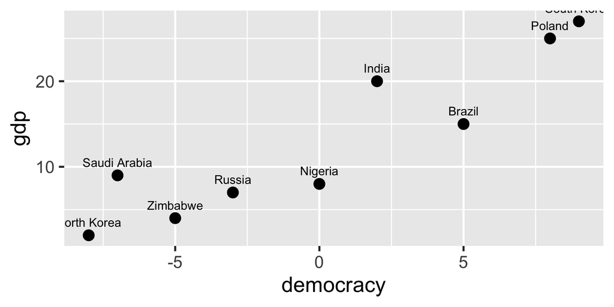

## Simple Geoms

### `geom_line`

Suppose we have data on average voter turnout (%) in national elections over several years. We want to see the trend in participation.

```r
# Toy dataset
eg3 <- data.frame(
  year = c(2000, 2004, 2008, 2012, 2016, 2020),
  turnout = c(55, 58, 62, 60, 59, 65))
```

## Simple Geoms

### `geom_line`

Suppose we have data on average voter turnout (%) in national elections over several years. We want to see the trend in participation.

```r
# Drawing the time line
ggplot(eg3, aes(x = year, y = turnout)) +
  geom_line()
```

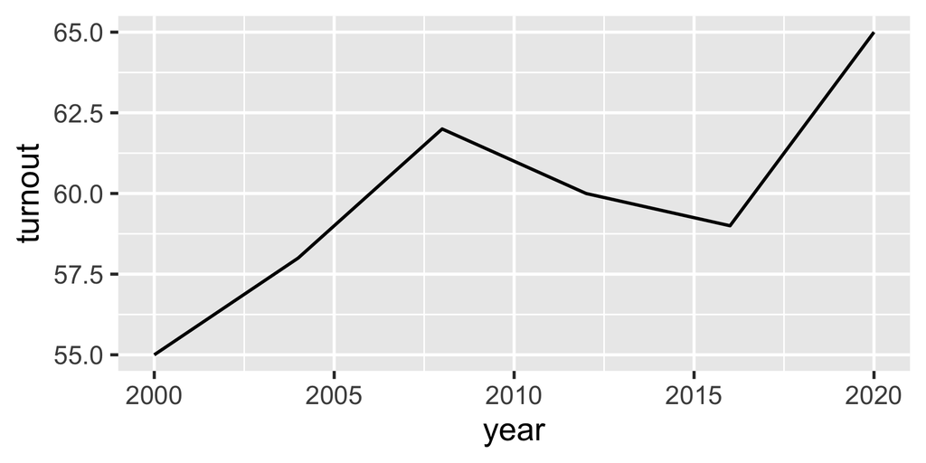

# Complex Geoms

## Complex Geoms

### Examples

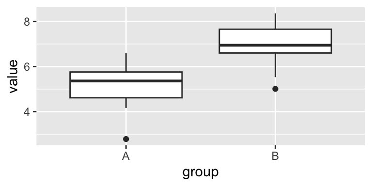

`geom_boxplot`

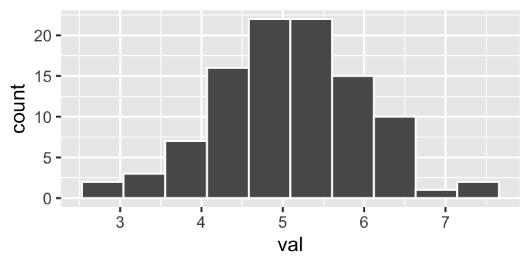

`geom_histogram`

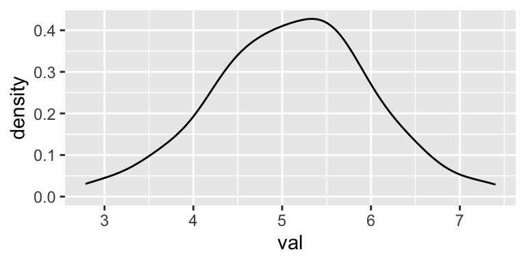

`geom_density`

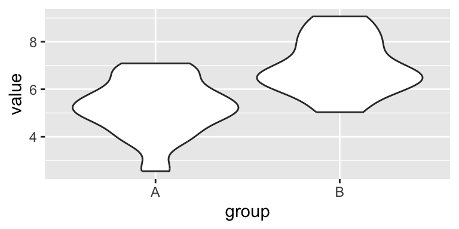

`geom_violin`

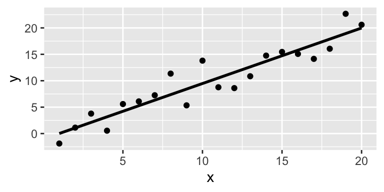

`geom_smooth`

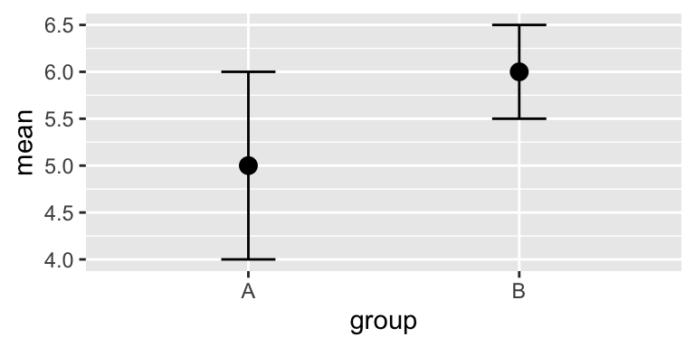

`geom_errorbar`

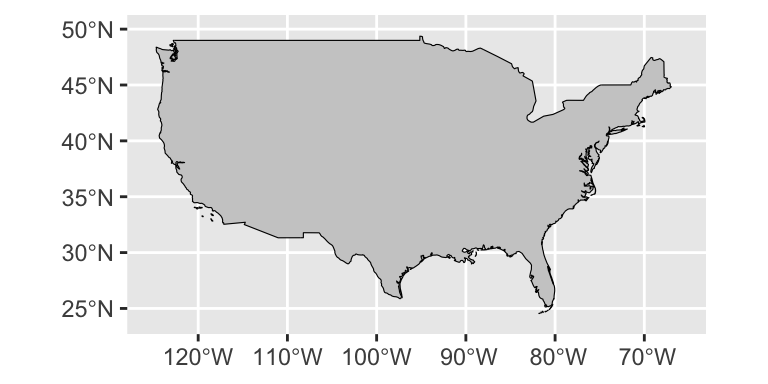

`geom_sf`